# OTX2 case study — Fig 3d

Cumulative distance from TSS to nearest 4C OTX2 peak, comparing three gene classes on day 2 of OTX2 KD:

- **Down**: log2FC < -1, baseMean > 5, p < 0.05
- **Nonmaternal**: D2-expressed but not 4C-activated
- **Up**: log2FC > 1, baseMean > 5, p < 0.05

Paper reports KS P = 3 × 10⁻³ for Down vs Nonmaternal. Paper: Wang et al. *Nat. Genet.* **57**, 2772-2784 (2025) 10.1038/s41588-025-02350-8

> **Upstream / preprocessing.** FASTQ → BAM → bigwig, MACS2 peak calling, Xia 2019 / Zou 2022 / Gifford 2013 downloads, and the one-off xlsx → TSV extractions are all documented in `preprocess.ipynb`. This notebook starts from the cached inputs under `/scratch/users/steorra/data/otx2/`.

## 1 · Setup

### RNA-seq FASTQ → DEG (not in preprocess.ipynb)

fig3d/fig3f consume the paper's DESeq2 DEG output (Supp Table S6). That workflow is RNA-seq-specific and outside `epione`'s epigenomics scope, so the recipe is kept inline here rather than in `preprocess.ipynb`.

```python
%%script false --no-raise-error
# =========================================================
# RNA-seq FASTQ -> gene counts -> DESeq2 DEG (Supp Table S6)
# =========================================================
# This block is specific to fig3d / fig3f (DEG-based analyses) — it is NOT
# part of epione's core scope (epione consumes bigwigs / peaks / TSVs),
# so it lives here instead of in preprocess.ipynb.
STAR --runThreadN 8 --runMode alignReads \
     --genomeDir /scratch/users/steorra/data/hg19/star_idx \
     --readFilesIn $FQDIR/${SAMPLE}_R1.fastq.gz $FQDIR/${SAMPLE}_R2.fastq.gz \
     --readFilesCommand zcat --outSAMtype BAM SortedByCoordinate \
     --outFileNamePrefix $BAMDIR/${SAMPLE}.
featureCounts -T 8 -p --countReadPairs \
     -a /scratch/users/steorra/data/hg19/gencode.v41lift37.annotation.gtf.gz \
     -o counts.tsv $BAMDIR/*.Aligned.sortedByCoord.out.bam
Rscript -e '
library(DESeq2)
counts <- as.matrix(read.table("counts.tsv", header=TRUE, row.names=1,
                                check.names=FALSE, skip=1)[,-(1:5)])
coldata <- data.frame(row.names = colnames(counts),
                      condition = factor(sub("_rep.*$", "", colnames(counts))))
dds <- DESeqDataSetFromMatrix(counts, coldata, ~ condition)
dds <- DESeq(dds)
res <- results(dds, contrast=c("condition","h_OTX2_KD_day2","h_OTX2_ctrl_day2"))
write.table(as.data.frame(res), "S6_D2_OTX2_KD_DEG.tsv", sep="\t", quote=FALSE)
'
```

```python
import os, pathlib, warnings
os.environ['PATH'] = '/scratch/users/steorra/env/omicdev/bin:' + os.environ.get('PATH', '')
warnings.filterwarnings('ignore', category=UserWarning)

import numpy as np
import pandas as pd
import matplotlib.pyplot as plt

import epione as epi
epi.pl.plot_set()

DATA         = pathlib.Path('/scratch/users/steorra/data/otx2')
OMIX         = DATA / 'OMIX006476'
ZOU          = DATA / 'GSE197265'
XIA          = DATA / 'GSE124718'
GIFFORD      = DATA / 'GSE61475'
SUPP_TABLES  = DATA / 'supp/supp_tables.xlsx'
GENCODE_GTF  = pathlib.Path('/scratch/users/steorra/data/hg19/gencode.v41lift37.annotation.gtf.gz')
```

[output not shown]

## 2 · Parse the D2-OTX2-KD DEG block from Supp Table S6

S6 stores multiple DEG blocks separated by header rows (`D2-OTX2-KD-DEG`, `D3-OTX2-KD-DEG`, …). This cell extracts just the D2 block.

```python
s6 = pd.read_excel(SUPP_TABLES, sheet_name='Table S6_DEG', header=None)
start = next(i for i,r in s6.iterrows() if isinstance(r[0],str) and 'D2-OTX2-KD-DEG' in r[0]) + 1
hdrs = [str(v).strip() for v in s6.iloc[start].values]
body, j = [], start + 1
while j < len(s6):
    v0 = s6.iloc[j, 0]
    if pd.isna(v0): break
    if isinstance(v0, str) and v0.endswith('DEG'): break
    body.append(s6.iloc[j].values); j += 1
seen = {}; uniq = []
for c in hdrs[:len(body[0])]:
    k = c if c not in ('nan','None','') else f'_drop{len(uniq)}'
    seen[k] = seen.get(k,0) + 1
    uniq.append(f'{k}_{seen[k]}' if seen[k] > 1 else k)
deg = pd.DataFrame(body, columns=uniq).loc[:, lambda d: ~d.columns.str.startswith('_drop')]
for c in ('baseMean','log2FoldChange','pvalue','padj'):
    deg[c] = pd.to_numeric(deg[c], errors='coerce')
print(f'DEG rows: {len(deg)}')
```

```
DEG rows: 769
```

## 3 · Build the three gene classes

Paper thresholds (Methods): |log2FC| > 1, baseMean > 5, p < 0.05.

```python
down = deg[(deg['log2FoldChange'] < -1) & (deg['baseMean'] > 5) & (deg['pvalue'] < 0.05)]
up   = deg[(deg['log2FoldChange'] >  1) & (deg['baseMean'] > 5) & (deg['pvalue'] < 0.05)]

s3 = pd.read_excel(SUPP_TABLES, sheet_name='Table S3_stage-activated genes', header=1)
s3.columns = [str(c).strip() for c in s3.columns]
col4c = next(c for c in s3.columns if '4-cell' in c.lower() or c.lower() == '4c')
activated_4c = set(s3[col4c].dropna().astype(str).str.strip()) - {'nan',''}
s4 = pd.read_excel(SUPP_TABLES, sheet_name='Table S4_OTX2 KD_RNA count', header=2)
s4.columns = [str(c).strip() for c in s4.columns]
nonmaternal = (set(s4[s4.columns[0]].dropna().astype(str).str.strip()) - {'nan',''}) - activated_4c

print(f'Down: {len(down)}   Up: {len(up)}   Nonmaternal: {len(nonmaternal)}')
```

```
Down: 643   Up: 126   Nonmaternal: 27973
```

## 4 · Map each gene to its TSS and build peak table

```python
gtf = epi.utils.get_gene_annotation(str(GENCODE_GTF))
gtf['tss'] = np.where(gtf['strand'] == '+', gtf['start'], gtf['end'])
gene2row = gtf.drop_duplicates('gene_name').set_index('gene_name')[['chrom','tss']]

peaks = pd.read_csv(OMIX / 'h_OTX2_day2_CUTRUN_rep12_peaks.bed',
                    sep='\t', header=None,
                    names=['chrom','start','end','name','score'])
peaks[['start','end']] = peaks[['start','end']].astype(int)
print(f'peaks: {len(peaks)}  gene->TSS: {len(gene2row)}')
```

```
peaks: 45521  gene->TSS: 20109
```

## 5 · Compute TSS→peak distances via `epi.utils.distance_to_nearest_peak`

Returns a numpy array (in bp) per input DataFrame; we convert to kb by passing `unit='kb'`.

```python
def _rows(genes): return gene2row.reindex(list(genes)).dropna().reset_index()
dists = {
    'Down':        epi.utils.distance_to_nearest_peak(_rows(down['gene'].astype(str)), peaks, unit='kb'),
    'Nonmaternal': epi.utils.distance_to_nearest_peak(_rows(nonmaternal),                peaks, unit='kb'),
    'Up':          epi.utils.distance_to_nearest_peak(_rows(up['gene'].astype(str)),   peaks, unit='kb'),
}
print({k: len(v) for k, v in dists.items()})
```

```
{'Down': 526, 'Nonmaternal': 18762, 'Up': 108}
```

## 6 · Plot cumulative distributions

`epi.pl.cumulative_distance` overlays step-CDF curves and can annotate the two-sided KS p-value between any two groups.

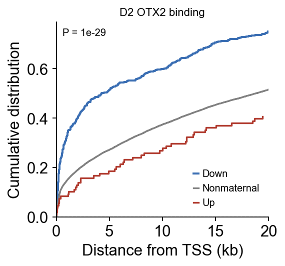

```python
fig, ax = epi.pl.cumulative_distance(
    dists,
    max_kb=20,
    colors={'Down': '#3A6EB3', 'Nonmaternal': '#808080', 'Up': '#B03A2E'},
    linewidths={'Down': 1.8},
    ks_between=('Down', 'Nonmaternal'),
    title='D2 OTX2 binding',
)
plt.show()
```